# WallMart Coursework in R

Installing Packages and Libraries

```r
install.packages("data.table")
library(data.table)
install.packages("ggplot2")
library(ggplot2)
install.packages("psych")
library(psych)
install.packages("corrplot")
library(corrplot)
install.packages("dplyr")
library(dplyr)
install.packages("plyr")
library(plyr)
install.packages("Amelia")
library(Amelia)
library(tidyr)
library(stringr)
library(dummies)
```

Setting the Working Directory & Loading the datasets as data frames

```r
#setwd("D:/RCW/")
train <- read.csv("D:/RCW/Train.csv")
test = read.csv("D:/RCW/Test.csv")
```

Printing the top 6 rows of the train & test data frames by using head()

```r
head(train)
```

|  | Item_Identifier | Item_Weight | Item_Fat_Content | Item_Visibility | Item_Type | Item_MRP | Outlet_Identifier | Outlet_Establishment_Year | Outlet_Size | Outlet_Location_Type | Outlet_Type | Item_Outlet_Sales |
| --- | --- | --- | --- | --- | --- | --- | --- | --- | --- | --- | --- | --- |
| 1 | FDA15 | 9.300 | Low Fat | 0.01604730 | Dairy | 249.8092 | OUT049 | 1999 | Medium | Tier 1 | Supermarket Type1 | 3735.1380 |
| 2 | DRC01 | 5.920 | Regular | 0.01927822 | Soft Drinks | 48.2692 | OUT018 | 2009 | Medium | Tier 3 | Supermarket Type2 | 443.4228 |
| 3 | FDN15 | 17.500 | Low Fat | 0.01676007 | Meat | 141.6180 | OUT049 | 1999 | Medium | Tier 1 | Supermarket Type1 | 2097.2700 |
| 4 | FDX07 | 19.200 | Regular | 0.00000000 | Fruits and Vegetables | 182.0950 | OUT010 | 1998 |  | Tier 3 | Grocery Store | 732.3800 |
| 5 | NCD19 | 8.930 | Low Fat | 0.00000000 | Household | 53.8614 | OUT013 | 1987 | High | Tier 3 | Supermarket Type1 | 994.7052 |
| 6 | FDP36 | 10.395 | Regular | 0.00000000 | Baking Goods | 51.4008 | OUT018 | 2009 | Medium | Tier 3 | Supermarket Type2 | 556.6088 |

```r
head(test)
```

|  | Item_Identifier | Item_Weight | Item_Fat_Content | Item_Visibility | Item_Type | Item_MRP | Outlet_Identifier | Outlet_Establishment_Year | Outlet_Size | Outlet_Location_Type | Outlet_Type |
| --- | --- | --- | --- | --- | --- | --- | --- | --- | --- | --- | --- |
| 1 | FDW58 | 20.750 | Low Fat | 0.007564836 | Snack Foods | 107.8622 | OUT049 | 1999 | Medium | Tier 1 | Supermarket Type1 |
| 2 | FDW14 | 8.300 | reg | 0.038427677 | Dairy | 87.3198 | OUT017 | 2007 |  | Tier 2 | Supermarket Type1 |
| 3 | NCN55 | 14.600 | Low Fat | 0.099574908 | Others | 241.7538 | OUT010 | 1998 |  | Tier 3 | Grocery Store |
| 4 | FDQ58 | 7.315 | Low Fat | 0.015388393 | Snack Foods | 155.0340 | OUT017 | 2007 |  | Tier 2 | Supermarket Type1 |
| 5 | FDY38 | NA | Regular | 0.118599314 | Dairy | 234.2300 | OUT027 | 1985 | Medium | Tier 3 | Supermarket Type3 |
| 6 | FDH56 | 9.800 | Regular | 0.063817206 | Fruits and Vegetables | 117.1492 | OUT046 | 1997 | Small | Tier 1 | Supermarket Type1 |

Checking the Dimensions of the dataset by using dim() The train dataset has 8523(rows) 12(cols) The test dataset has 5681(rows) 11(cols)

```r
dim(train)
```

```
[1] 8523   12
```

```r
dim(test)
```

```
[1] 5681   11
```

Checking the column names to find the missing columns We find the ‘Item_Outlet_Sales’ is missing from test dataset. This is because we will be predicting the values of ‘Item_Outlet_Sales’

```r
names(train)
```

```
 [1] "Item_Identifier"           "Item_Weight"               "Item_Fat_Content"
 [4] "Item_Visibility"           "Item_Type"                 "Item_MRP"
 [7] "Outlet_Identifier"         "Outlet_Establishment_Year" "Outlet_Size"
[10] "Outlet_Location_Type"      "Outlet_Type"               "Item_Outlet_Sales"
```

```r
names(test)
```

```
 [1] "Item_Identifier"           "Item_Weight"               "Item_Fat_Content"
 [4] "Item_Visibility"           "Item_Type"                 "Item_MRP"
 [7] "Outlet_Identifier"         "Outlet_Establishment_Year" "Outlet_Size"
[10] "Outlet_Location_Type"      "Outlet_Type"
```

Checking if this data has missing values. We are using table to group the values by False and True. We find 1463 NA values in the train dataset.

```r
table(is.na(train))
```

```
 FALSE   TRUE
100813   1463
```

Checking the variables wisth the count of NA values. We find only Item_Weight has the 1463 NA values.

```r
colSums(is.na(train))
```

```
          Item_Identifier               Item_Weight          Item_Fat_Content           Item_Visibility
                        0                      1463                         0                         0
                Item_Type                  Item_MRP         Outlet_Identifier Outlet_Establishment_Year
                        0                         0                         0                         0
              Outlet_Size      Outlet_Location_Type               Outlet_Type         Item_Outlet_Sales
                        0                         0                         0                         0
```

Checking the variables and their types in train dataset

```r
str(train)
```

```
'data.frame':   8523 obs. of  12 variables:
 $ Item_Identifier          : Factor w/ 1559 levels "DRA12","DRA24",..: 157 9 663 1122 1298 759 697 739 441 991 ...
 $ Item_Weight              : num  9.3 5.92 17.5 19.2 8.93 ...
 $ Item_Fat_Content         : Factor w/ 5 levels "LF","low fat",..: 3 5 3 5 3 5 5 3 5 5 ...
 $ Item_Visibility          : num  0.016 0.0193 0.0168 0 0 ...
 $ Item_Type                : Factor w/ 16 levels "Baking Goods",..: 5 15 11 7 10 1 14 14 6 6 ...
 $ Item_MRP                 : num  249.8 48.3 141.6 182.1 53.9 ...
 $ Outlet_Identifier        : Factor w/ 10 levels "OUT010","OUT013",..: 10 4 10 1 2 4 2 6 8 3 ...
 $ Outlet_Establishment_Year: int  1999 2009 1999 1998 1987 2009 1987 1985 2002 2007 ...
 $ Outlet_Size              : Factor w/ 4 levels "","High","Medium",..: 3 3 3 1 2 3 2 3 1 1 ...
 $ Outlet_Location_Type     : Factor w/ 3 levels "Tier 1","Tier 2",..: 1 3 1 3 3 3 3 3 2 2 ...
 $ Outlet_Type              : Factor w/ 4 levels "Grocery Store",..: 2 3 2 1 2 3 2 4 2 2 ...
 $ Item_Outlet_Sales        : num  3735 443 2097 732 995 ...
```

We will see a summary of the train dataset.

```r
summary(train)
```

```
 Item_Identifier  Item_Weight     Item_Fat_Content Item_Visibility                   Item_Type
 FDG33  :  10    Min.   : 4.555   LF     : 316     Min.   :0.00000   Fruits and Vegetables:1232
 FDW13  :  10    1st Qu.: 8.774   low fat: 112     1st Qu.:0.02699   Snack Foods          :1200
 DRE49  :   9    Median :12.600   Low Fat:5089     Median :0.05393   Household            : 910
 DRN47  :   9    Mean   :12.858   reg    : 117     Mean   :0.06613   Frozen Foods         : 856
 FDD38  :   9    3rd Qu.:16.850   Regular:2889     3rd Qu.:0.09459   Dairy                : 682
 FDF52  :   9    Max.   :21.350                    Max.   :0.32839   Canned               : 649
 (Other):8467    NA's   :1463                                        (Other)              :2994
    Item_MRP      Outlet_Identifier Outlet_Establishment_Year Outlet_Size   Outlet_Location_Type
 Min.   : 31.29   OUT027 : 935      Min.   :1985                    :2410   Tier 1:2388
 1st Qu.: 93.83   OUT013 : 932      1st Qu.:1987              High  : 932   Tier 2:2785
 Median :143.01   OUT035 : 930      Median :1999              Medium:2793   Tier 3:3350
 Mean   :140.99   OUT046 : 930      Mean   :1998              Small :2388
 3rd Qu.:185.64   OUT049 : 930      3rd Qu.:2004
 Max.   :266.89   OUT045 : 929      Max.   :2009
                  (Other):2937
            Outlet_Type   Item_Outlet_Sales
 Grocery Store    :1083   Min.   :   33.29
 Supermarket Type1:5577   1st Qu.:  834.25
 Supermarket Type2: 928   Median : 1794.33
 Supermarket Type3: 935   Mean   : 2181.29
                          3rd Qu.: 3101.30
                          Max.   :13086.97
```

From the above information we can:

Exploring the Numerical Columns:

1.Item_Weight - There are 1463 NA Values

2.Item Visibility - Contains no NA Values, but contains 0 values.

3.Item_MRP - Contains No NA/0 values.Also has an acceptable price range with no outliers.

5.Item_Outlet_Sales - Contains no NA/0 values.

Exploring the Factor Columns:

1.Item_Identifier - Contains 1559 unique values

```r
#install.packages("plyr")
#library(plyr)
#library(dplyr)
train %>%
  summarise(n_distinct(Item_Identifier))
```

| n_distinct(Item_Identifier) |
| --- |
| 1559 |

2.Item_Fat_Content - We find the level values Low Fat/low fat/LF are same but typed incorrectly.

```r
train %>%
group_by(Item_Fat_Content) %>% summarise(Count = n()) %>% arrange(desc(Count))
```

| Item_Fat_Content | Count |
| --- | --- |
| Low Fat | 5089 |
| Regular | 2889 |
| LF | 316 |
| reg | 117 |
| low fat | 112 |

3.Item_Type - Categories of Items with counts

```r
train%>%
group_by(Item_Type) %>%
summarise(Count = n()) %>% arrange(desc(Count))
```

| Item_Type | Count |
| --- | --- |
| Fruits and Vegetables | 1232 |
| Snack Foods | 1200 |
| Household | 910 |
| Frozen Foods | 856 |
| Dairy | 682 |
| Canned | 649 |
| Baking Goods | 648 |
| Health and Hygiene | 520 |
| Soft Drinks | 445 |
| Meat | 425 |

[output cut: 6 more lines]

4.Outlet_Identifier - There are Item information from 10 different Outlets

```r
train %>%
group_by(Outlet_Identifier) %>%
summarise(Count = n()) %>% arrange(desc(Count))
```

| Outlet_Identifier | Count |
| --- | --- |
| OUT027 | 935 |
| OUT013 | 932 |
| OUT035 | 930 |
| OUT046 | 930 |
| OUT049 | 930 |
| OUT045 | 929 |
| OUT018 | 928 |
| OUT017 | 926 |
| OUT010 | 555 |
| OUT019 | 528 |

5.Outlet_Size - Outlet Size data not properly levelled. (2410 counts)

```r
train%>%
group_by(Outlet_Size) %>% summarise(Count = n())
```

| Outlet_Size | Count |
| --- | --- |
|  | 2410 |
| High | 932 |
| Medium | 2793 |
| Small | 2388 |

```r
train%>%
group_by(Outlet_Location_Type) %>%
summarise(Count = n()) %>% arrange(desc(Count))
```

| Outlet_Location_Type | Count |
| --- | --- |
| Tier 3 | 3350 |
| Tier 2 | 2785 |
| Tier 1 | 2388 |

7.Outlet_Type - We find the Types of Outlet

```r
train%>%
group_by(Outlet_Type)%>%
summarise(Count=n())%>% arrange(desc(Count))
```

| Outlet_Type | Count |
| --- | --- |
| Supermarket Type1 | 5577 |
| Grocery Store | 1083 |
| Supermarket Type3 | 935 |
| Supermarket Type2 | 928 |

Data Manipulation

```r
test$Item_Outlet_Sales <- 1
names(test)
```

```
 [1] "Item_Identifier"           "Item_Weight"               "Item_Fat_Content"
 [4] "Item_Visibility"           "Item_Type"                 "Item_MRP"
 [7] "Outlet_Identifier"         "Outlet_Establishment_Year" "Outlet_Size"
[10] "Outlet_Location_Type"      "Outlet_Type"               "Item_Outlet_Sales"
```

Now, we are combining thee train and test data with rbind function

```r
combi <- rbind(train, test)
dim(combi)
```

```
[1] 14204    12
```

We are imputing the NA values in Item_Weight with the median of the values of the column. To calculate the median of the non-missing values if are passing the argument na.rm=TRUE

```r
combi$Item_Weight[is.na(combi$Item_Weight)] <- median(combi$Item_Weight, na.rm = TRUE)
summary(combi$Item_Weight)
```

```
   Min. 1st Qu.  Median    Mean 3rd Qu.    Max.
  4.555   9.300  12.600  12.760  16.000  21.350
```

There are 0 values in in Item_visibility, therefore, we also impute the 0s with median of the column values.

```r
combi$Item_Visibility <- ifelse(combi$Item_Visibility == 0, median(combi$Item_Visibility),combi$Item_Visibility)
summary(combi$Item_Visibility)
```

```
    Min.  1st Qu.   Median     Mean  3rd Qu.     Max.
0.003575 0.033143 0.054023 0.069296 0.094037 0.328391
```

Renaming the blank level in of Outlet_Size to ‘Other’

```r
levels(combi$Outlet_Size)[1] <- "Other"
table(combi$Outlet_Size)
```

```
 Other   High Medium  Small
  4016   1553   4655   3980
```

Renaming the levels of Item_Fat_Content to ‘Low Fat’ & ‘Regular’

```r
#library(plyr)
#combi$Item_Fat_Content <- revalue(combi$Item_Fat_Content,c("LF" = "Low Fat", "reg" = "Regular", "low fat" = "Low Fat"))
table(combi$Item_Fat_Content)
```

[output not shown]

Data Visualisation

```r
combi_encoded=as.data.frame(combi)
str(combi_encoded)
```

```
'data.frame':   14204 obs. of  12 variables:
 $ Item_Identifier          : Factor w/ 1559 levels "DRA12","DRA24",..: 157 9 663 1122 1298 759 697 739 441 991 ...
 $ Item_Weight              : num  9.3 5.92 17.5 19.2 8.93 ...
 $ Item_Fat_Content         : Factor w/ 2 levels "Low Fat","Regular": 1 2 1 2 1 2 2 1 2 2 ...
 $ Item_Visibility          : num  0.016 0.0193 0.0168 0.054 0.054 ...
 $ Item_Type                : Factor w/ 16 levels "Baking Goods",..: 5 15 11 7 10 1 14 14 6 6 ...
 $ Item_MRP                 : num  249.8 48.3 141.6 182.1 53.9 ...
 $ Outlet_Identifier        : Factor w/ 10 levels "OUT010","OUT013",..: 10 4 10 1 2 4 2 6 8 3 ...
 $ Outlet_Establishment_Year: int  1999 2009 1999 1998 1987 2009 1987 1985 2002 2007 ...
 $ Outlet_Size              : Factor w/ 4 levels "Other","High",..: 3 3 3 1 2 3 2 3 1 1 ...
 $ Outlet_Location_Type     : Factor w/ 3 levels "Tier 1","Tier 2",..: 1 3 1 3 3 3 3 3 2 2 ...
 $ Outlet_Type              : Factor w/ 4 levels "Grocery Store",..: 2 3 2 1 2 3 2 4 2 2 ...
 $ Item_Outlet_Sales        : num  3735 443 2097 732 995 ...
```

Dividing data to Train & Test before Label & Hot Encoding

```r
new_train_combi <- combi %>% filter(Item_Outlet_Sales != 1)
new_test_combi <- combi %>% filter(Item_Outlet_Sales == 1)
str(new_train_combi)
str(new_test_combi)
```

[output not shown]

We have tried to visualise Item_Outlet_Sales with different Categorical Values

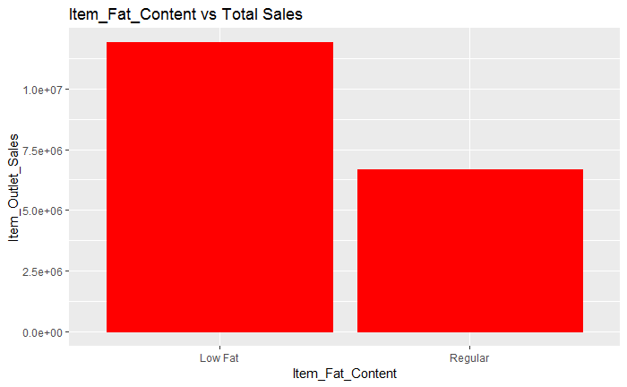

```r
ggplot(new_train_combi, aes(Item_Fat_Content, Item_Outlet_Sales)) + geom_bar(stat = "identity", color = "red") + ggtitle("Item_Fat_Content vs Total Sales")
```

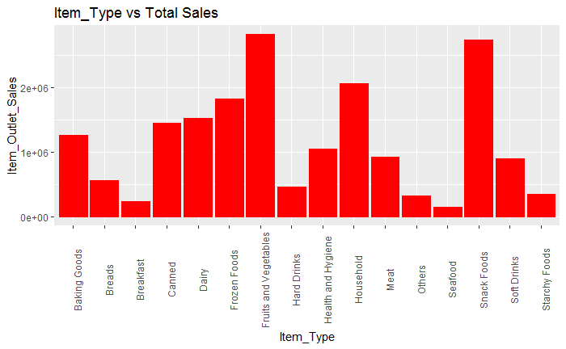

```r
ggplot(new_train_combi, aes(Item_Type, Item_Outlet_Sales)) + geom_bar(stat = "identity", color = "red") + theme(axis.text.x = element_text(angle = 90), axis.text.y = element_text(angle = 0)) + ggtitle("Item_Type vs Total Sales")
```

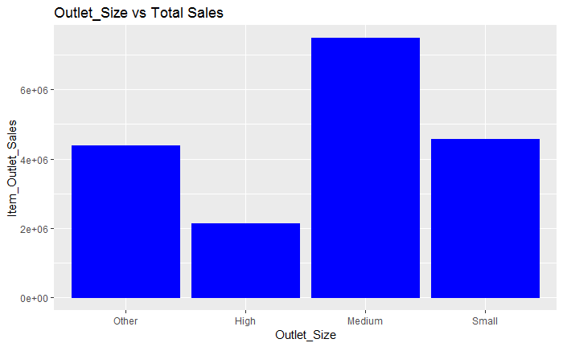

```r
ggplot(new_train_combi, aes(Outlet_Size, Item_Outlet_Sales)) + geom_bar(stat = "identity", color = "blue") + ggtitle("Outlet_Size vs Total Sales")
```